# R Training: 00 - Intro and Setup

Pricing Innovation Team

# 1 R Installation

**Step 1)** R must be installed before we can begin using it. The installer for R 3.6.1 can be found here:

R Installer

Please ensure that R is installed in C:/R (Create the folder R if it is not there).

**Step 2)** R Studio (an integrated development environment) can be installed from the link below or installed through **Software Center**. This tool will be use to code in R.

If you are unable to find it in software center, you can copy the following folder into your C:/R Drive

*S:/Pricing/Innovation/R Ressources/Pre-installed folders/RStudio-1.2.1355*

You can then open the following to get access to the software

*C:/RStudio-1.2.1355/bin/rstudio.exe*

# 2 R Libraries

Many packages have already been written and are available through either CRAN, github or our own local packages. Packages contain a series of functions for accomplishing tasks focused on a common theme. For example, plotly focuses on creating visualizations whereas dplyr focuses on data manipulation.

We will first write out all the necessary CRAN package names to your required.packages vector for your specific needs. We choose to keep the loading of our own packages separate, since it is not installed through CRAN.

## 2.1 CRAN Installation

Let’s install some of the common packages we’ll need later on. If you already have those packages, R will only load them. You can reuse this code for future projects.

```r
required.packages <- c("dplyr",
                       "fst",
                       "pryr",
                       "plotly",
                       "htmlwidgets",
                       "knitr",
                       "Rcpp",
                       "rmarkdown",
                       "data.table",
                       "RcppParallel",
                       "tidyverse",
                       "XLConnect",
                       "foreach")

# Load all packages & Install packages if needed
for(package in required.packages){
  package.Loaded <- require(package, character.only = TRUE)
  if(!package.Loaded){
    install.packages(package, dependencies = TRUE, repos = "http://cran.us.r-project.org")
  }
  require(package, character.only = TRUE)
}
```

Once package is installed, run library(PACKAGE_NAME) to load that package and gain access to it’s functions.

Here’s an example of using the library function

```r
library(Rcpp)
```

## 2.2 Local Package Installation

For an example of installing local packages, we will install our JAVAPACK and RUO package using zip files which will be needed for our lessons

[figure not shown]

Go to the Tools->Install Packages…

Most recent version of our JAVAPACK and RUO package can be found here:

*S:/Pricing/Innovation/R Ressources/Packages*

On this menu we can set the option of Install to Package Archive File

We can then choose Browse to the proper package.

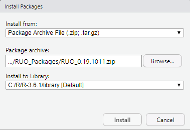

RUO Installation

If this is your first time using R, it is very likely that when you try to install RUO you will be missing some packages that are required for installation. R will notify you which packages you require to install RUO. These packages are called dependancies because functions in the desired package (RUO) depend on functions in the dependency package.

# 3 R Studio User Interface

R studio offers a very user friendly interface that allows users to code and keep track of variables, packages, plots and other outputs.

**Pane 1 Code Editor** Our code will be written here. We can save it, and whatever is typed is not ran automatically. Must press run or run all which will send the code to the console

**Pane 2: R Console** Our output and error messages will appear hear. It is also very useful for debugging our code as you can write in it if necessary

**Pane 3 Workspace and History** Our variables will be here and we are able to keep track of the type of variables that are in our R session and details about these such as whether it is Data or a Value.

**Pane 4 Plots and Files** The plots we generate will show up here. We can also look at our different available packages.

# 4 R Basics

## 4.1 R Operators

For any coding language operators for testing TRUE or FALSE, adding and subtracting exist. For those who are new to R or new to programming we recommend looking through this short page on R operators [R Operators](https://www.datamentor.io/r-programming/operator/)

## 4.2 Keyboard Shortcuts

### 4.2.1 Running Code

When running your code from your Code Editor instead of pressing run you can either use the shortcut **ctlr+shift+enter** which runs all code and **ctrl+enter** which runs only the line you’re currently on

### 4.2.2 Useful Operators

To create the <- operator which is our assignment operator we simply can press **alt and -**

To create the %>% operator which is our piping operator that is used commonly in some packages like dplyr and plotly you can press **ctrl + shift + m**

To perform an undo or redo the keyboard shortcut is **ctrl + z** and **ctrl + shift + z** respectively

To save your document the keydoard shortcut is **ctrl + s**